# Did the New Landing Page Really Win?

An A/B test analysis in R — separating real lift from random chance

Manjiri Gajmal · Freelance Data Scientist

October 2026

```r
ab <- read.csv("data/ab_test_landing_page.csv", stringsAsFactors = FALSE) %>%
  mutate(date    = as.Date(date),
         variant = factor(variant, levels = c("A", "B")),
         weekend = weekdays(date) %in% c("Saturday", "Sunday"))

summ <- ab %>%
  group_by(variant) %>%
  summarise(visitors    = n(),
            conversions = sum(converted),
            conv_rate   = mean(converted),
            revenue     = sum(revenue),
            rpv         = mean(revenue),
            .groups = "drop")

pA <- summ$conv_rate[1]; pB <- summ$conv_rate[2]
nA <- summ$visitors[1];  nB <- summ$visitors[2]
xA <- summ$conversions[1]; xB <- summ$conversions[2]

ztest <- prop.test(c(xB, xA), c(nB, nA), correct = FALSE)
abs_diff <- pB - pA
rel_lift <- pB / pA - 1

# Bootstrap CI for relative lift (computed early so the summary can quote it)
set.seed(7)
lift_ci_es <- quantile(replicate(5000,
  mean(sample(ab$converted[ab$variant == "B"], replace = TRUE)) /
  mean(sample(ab$converted[ab$variant == "A"], replace = TRUE)) - 1), c(.025, .975))
```

# Executive summary

**Business question.** An online *Excel: Beginner to Advanced* course tested a redesigned landing page (**B**: testimonials above the fold, a shorter form, a clearer call-to-action) against the current page (**A**) for 28 days, with 28,905 visitors split at random.

**Answer.** Version B converted **3.11%** of visitors vs **2.66%** for A — a **17% relative lift** (p = 0.022). Five independent checks (z-test, permutation test, Bayesian model, regression with controls, and a data-quality audit) all point the same way: **the lift is very unlikely to be chance.**

**Recommendation.** Roll out B on mobile now; keep testing on desktop; track revenue for another cycle before booking the gain in a forecast.

# 1. Experiment design: how big did the test need to be?

Before looking at results, a good analyst asks: *was this test even capable of detecting the effect we care about?* An under-powered test produces noisy “winners” that never replicate.

```r
baseline <- 0.03     # historical conversion rate of page A
mde_rel  <- 0.20     # smallest lift worth acting on: +20% relative
pw <- power.prop.test(p1 = baseline, p2 = baseline * (1 + mde_rel),
                      sig.level = 0.05, power = 0.80)
n_needed <- ceiling(pw$n)

data.frame(
  Assumption = c("Baseline conversion (A)", "Minimum detectable effect",
                 "Significance level (α)", "Power (1 − β)",
                 "Visitors needed per variant", "Visitors actually collected per variant"),
  Value = c(pct(baseline, 1), paste0("+", pct(mde_rel, 0), " relative (",
                                     pct(baseline, 1), " → ", pct(baseline * 1.2, 1), ")"),
            "0.05", "80%", comma(n_needed), paste(comma(nA), "/", comma(nB)))
)
```

| Assumption | Value |
| --- | --- |
| Baseline conversion (A) | 3.0% |
| Minimum detectable effect | +20% relative (3.0% → 3.6%) |
| Significance level (α) | 0.05 |
| Power (1 − β) | 80% |
| Visitors needed per variant | 13,914 |
| Visitors actually collected per variant | 14,505 / 14,400 |

The plan called for **13,914 visitors per variant**; the test collected **14,400+** per variant — so it met its power target, and the decision date was fixed in advance (28 days). That second point matters a lot; Section 8 shows why.

# 2. Data quality: can we trust the split?

## Sample Ratio Mismatch (SRM) check

If a 50/50 test doesn’t deliver roughly 50/50 traffic, something is broken (redirect bugs, bots, tracking failures) and **no downstream result can be trusted**. A chi-square goodness-of-fit test catches this.

```r
srm <- chisq.test(c(nA, nB), p = c(0.5, 0.5))
data.frame(Variant = c("A", "B"), Visitors = comma(c(nA, nB)),
           Share = pct(c(nA, nB) / (nA + nB), 1),
           `SRM p-value` = c(fmtp(srm$p.value), ""), check.names = FALSE)
```

| Variant | Visitors | Share | SRM p-value |
| --- | --- | --- | --- |
| A | 14,505 | 50.2% | 0.537 |
| B | 14,400 | 49.8% |  |

p = 0.537 (well above the usual 0.01 alarm threshold) → **no sample ratio mismatch**. Traffic was split as designed.

## Daily traffic & mix balance

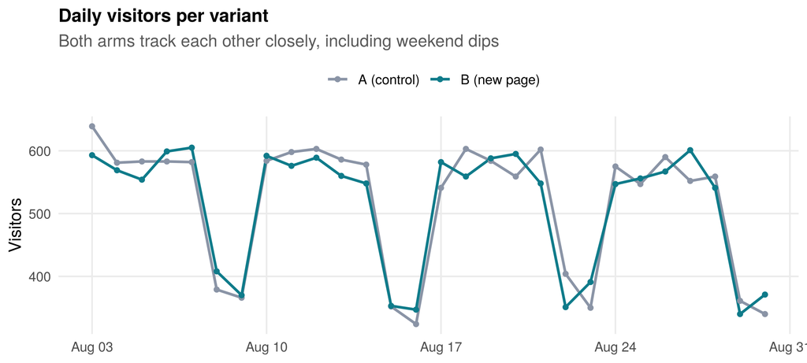

```r
ab %>% count(date, variant) %>%
  ggplot(aes(date, n, colour = variant)) +
  geom_line(linewidth = 0.9) + geom_point(size = 1.4) +
  scale_colour_manual(values = pal, labels = c("A (control)", "B (new page)")) +
  labs(title = "Daily visitors per variant",
       subtitle = "Both arms track each other closely, including weekend dips",
       x = NULL, y = "Visitors")
```

```r
bal <- ab %>%
  pivot_longer(c(device, source), names_to = "dimension", values_to = "level") %>%
  count(dimension, level, variant) %>%
  group_by(dimension, variant) %>% mutate(share = n / sum(n)) %>% ungroup() %>%
  select(-n) %>% pivot_wider(names_from = variant, values_from = share) %>%
  mutate(Difference = A - B)

bal %>% mutate(across(c(A, B), ~ pct(.x, 1)),
               Difference = paste0(round(Difference * 100, 1), " pp")) %>%
  rename(Dimension = dimension, Level = level, `Share in A` = A, `Share in B` = B)
```

| Dimension | Level | Share in A | Share in B | Difference |
| --- | --- | --- | --- | --- |
| device | Desktop | 35.2% | 35.5% | -0.3 pp |
| device | Mobile | 57.9% | 57.9% | 0.1 pp |
| device | Tablet | 6.9% | 6.7% | 0.2 pp |
| source | Email | 18.4% | 18.4% | -0.1 pp |
| source | Organic search | 37.7% | 37.8% | 0 pp |
| source | Paid social | 32.2% | 32.1% | 0.1 pp |
| source | Referral | 11.7% | 11.8% | 0 pp |

Device and channel mix differ by well under one percentage point between arms — randomisation did its job, so differences in outcomes can be attributed to the page itself.

# 3. Primary metric: conversion rate

```r
summ %>%
  transmute(Variant = c("A (control)", "B (new page)"),
            Visitors = comma(visitors), Enrolments = comma(conversions),
            `Conversion rate` = pct(conv_rate))
```

| Variant | Visitors | Enrolments | Conversion rate |
| --- | --- | --- | --- |
| A (control) | 14,505 | 386 | 2.66% |
| B (new page) | 14,400 | 448 | 3.11% |

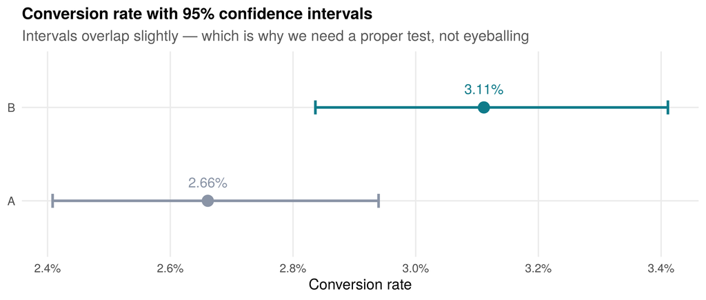

```r
ci <- summ %>% rowwise() %>%
  mutate(lo = prop.test(conversions, visitors)$conf.int[1],
         hi = prop.test(conversions, visitors)$conf.int[2]) %>% ungroup()

ggplot(ci, aes(conv_rate, variant, colour = variant)) +
  geom_errorbarh(aes(xmin = lo, xmax = hi), height = 0.15, linewidth = 1) +
  geom_point(size = 4) +
  geom_text(aes(label = pct(conv_rate)), vjust = -1.3, size = 4, show.legend = FALSE) +
  scale_colour_manual(values = pal) +
  scale_x_continuous(labels = percent_format(accuracy = 0.1)) +
  labs(title = "Conversion rate with 95% confidence intervals",
       subtitle = "Intervals overlap slightly — which is why we need a proper test, not eyeballing",
       x = "Conversion rate", y = NULL) +
  theme(legend.position = "none")
```

## Two-proportion z-test

```r
# Confidence interval for the relative lift via bootstrap (lift is a ratio,
# so the z-test's interval for the difference doesn't apply directly).
# Computed in the setup chunk: 5,000 resamples of each arm.
lift_ci <- unname(lift_ci_es)

data.frame(
  Measure = c("Absolute difference (B − A)", "95% CI for absolute difference",
              "Relative lift", "95% CI for relative lift (bootstrap)",
              "z-test p-value"),
  Value = c(paste0("+", round(abs_diff * 100, 2), " pp"),
            paste0("[", round(ztest$conf.int[1] * 100, 2), " pp, ",
                   round(ztest$conf.int[2] * 100, 2), " pp]"),
            paste0("+", pct(rel_lift, 1)),
            paste0("[", pct(lift_ci[1], 1), ", ", pct(lift_ci[2], 1), "]"),
            fmtp(ztest$p.value))
)
```

| Measure | Value |
| --- | --- |
| Absolute difference (B − A) | +0.45 pp |
| 95% CI for absolute difference | [0.06 pp, 0.84 pp] |
| Relative lift | +16.9% |
| 95% CI for relative lift (bootstrap) | [1.9%, 33.6%] |
| z-test p-value | 0.022 |

**Reading this like a stakeholder:** if the two pages were truly identical, a gap this large would show up only about 2.2% of the time. The confidence interval excludes zero, but it is **wide** — the true lift could plausibly be anywhere from about 2% to 34%. That width is the honest part of the story, and it shapes the recommendation.

# 4. “Was it just chance?” — two independent answers

A single p-value is easy to over-trust. Here are two different ways of asking the same question that don’t rely on the z-test’s assumptions.

## 4a. Permutation test: shuffle the labels 10,000 times

If the page made no difference, then the “A” and “B” labels are meaningless — so we can shuffle them at random and see how often chance alone produces a gap as big as the one we observed.

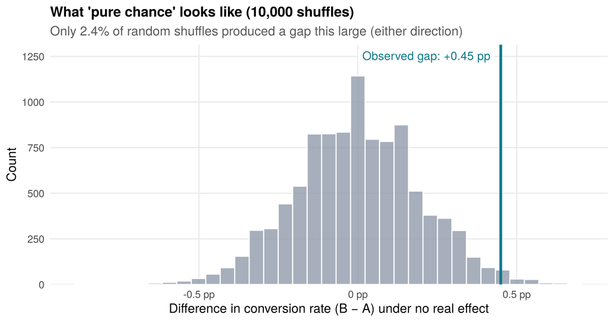

```r
n_perm <- 10000
conv   <- ab$converted
is_B   <- ab$variant == "B"
obs    <- mean(conv[is_B]) - mean(conv[!is_B])

perm_diffs <- replicate(n_perm, {
  s <- sample(is_B)
  mean(conv[s]) - mean(conv[!s])
})
perm_p <- mean(abs(perm_diffs) >= abs(obs))

ggplot(data.frame(d = perm_diffs), aes(d)) +
  geom_histogram(bins = 35, fill = col_A, alpha = 0.75, colour = "white") +
  geom_vline(xintercept = obs, colour = col_B, linewidth = 1.2) +
  annotate("label", x = obs, y = Inf, vjust = 1.2, hjust = 1.05,
           label = paste0("Observed gap: +", round(obs * 100, 2), " pp"),
           colour = col_B, fill = "white", label.size = 0) +
  scale_y_continuous(expand = expansion(mult = c(0, 0.15))) +
  scale_x_continuous(labels = function(x) paste0(round(x * 100, 1), " pp")) +
  labs(title = "What 'pure chance' looks like (10,000 shuffles)",
       subtitle = paste0("Only ", pct(perm_p, 1),
                         " of random shuffles produced a gap this large (either direction)"),
       x = "Difference in conversion rate (B − A) under no real effect", y = "Count")
```

Permutation p-value: **0.024** — closely agreeing with the z-test, with no distributional assumptions at all.

## 4b. Bayesian view: what’s the probability B is actually better?

Business stakeholders rarely want a p-value — they want *“how sure are we B is better, and how much could we lose if we’re wrong?”* A Beta-Binomial model answers that directly.

```r
draws <- 100000
post_A <- rbeta(draws, 1 + xA, 1 + nA - xA)   # uniform Beta(1,1) prior
post_B <- rbeta(draws, 1 + xB, 1 + nB - xB)

prob_B_better <- mean(post_B > post_A)
post_lift     <- post_B / post_A - 1
prob_10       <- mean(post_lift > 0.10)
exp_loss_B    <- mean(pmax(post_A - post_B, 0))  # expected conversion loss if we ship B

data.frame(
  Question = c("Probability B beats A", "Probability lift exceeds +10%",
               "95% credible interval for lift",
               "Expected loss if we ship B and we're wrong"),
  Answer = c(pct(prob_B_better, 1), pct(prob_10, 1),
             paste0("[", pct(quantile(post_lift, .025), 1), ", ",
                    pct(quantile(post_lift, .975), 1), "]"),
             paste0(signif(exp_loss_B * 100, 2), " pp of conversion (tiny)"))
)
```

| Question | Answer |
| --- | --- |
| Probability B beats A | 98.9% |
| Probability lift exceeds +10% | 81.3% |
| 95% credible interval for lift | [2.1%, 33.7%] |
| Expected loss if we ship B and we’re wrong | 0.00073 pp of conversion (tiny) |

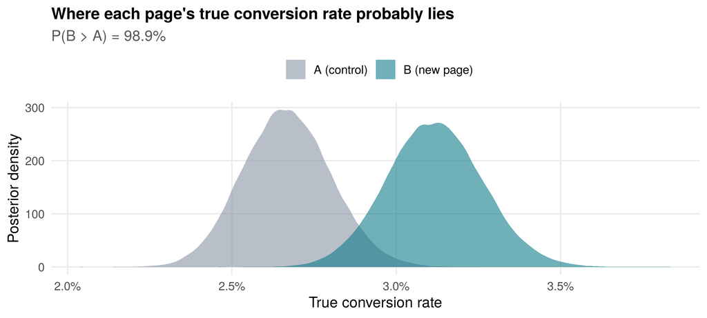

```r
data.frame(rate = c(post_A, post_B),
           variant = rep(c("A", "B"), each = draws)) %>%
  ggplot(aes(rate, fill = variant)) +
  geom_density(alpha = 0.6, colour = NA) +
  scale_fill_manual(values = pal, labels = c("A (control)", "B (new page)")) +
  scale_x_continuous(labels = percent_format(accuracy = 0.1)) +
  labs(title = "Where each page's true conversion rate probably lies",
       subtitle = paste0("P(B > A) = ", pct(prob_B_better, 1)),
       x = "True conversion rate", y = "Posterior density")
```

There is a **99% probability B is genuinely better**, and the downside risk of shipping it is negligible. That’s a decision a manager can act on.

# 5. Secondary metric: revenue per visitor

Conversions only matter if they turn into money. Revenue per visitor (RPV) is harder to test because it’s extremely skewed: ~97% of visitors spend $0, and buyers pay either $49 (Standard) or $129 (Pro bundle).

```r
rev_A <- ab$revenue[ab$variant == "A"]
rev_B <- ab$revenue[ab$variant == "B"]
welch <- t.test(rev_B, rev_A)

boot_rpv <- replicate(5000, mean(sample(rev_B, replace = TRUE)) -
                            mean(sample(rev_A, replace = TRUE)))
rpv_ci <- quantile(boot_rpv, c(0.025, 0.975))

pro_mix <- ab %>% filter(converted == 1) %>% group_by(variant) %>%
  summarise(pro_share = mean(revenue == 129), aov = mean(revenue), .groups = "drop")

data.frame(
  Measure = c("Revenue per visitor — A", "Revenue per visitor — B",
              "Difference (B − A)", "95% CI (bootstrap)", "Welch t-test p-value",
              "Avg. order value — A / B", "Pro bundle share of buyers — A / B"),
  Value = c(dollar(mean(rev_A), 0.01), dollar(mean(rev_B), 0.01),
            dollar(mean(rev_B) - mean(rev_A), 0.01),
            paste0("[", dollar(rpv_ci[1], 0.01), ", ", dollar(rpv_ci[2], 0.01), "]"),
            fmtp(welch$p.value),
            paste(dollar(pro_mix$aov, 0.01), collapse = " / "),
            paste(pct(pro_mix$pro_share, 1), collapse = " / "))
)
```

| Measure | Value |
| --- | --- |
| Revenue per visitor — A | $2.04 |
| Revenue per visitor — B | $2.18 |
| Difference (B − A) | $0.14 |
| 95% CI (bootstrap) | [-$0.17, $0.45] |
| Welch t-test p-value | 0.397 |
| Avg. order value — A / B | $76.77 / $70.07 |
| Pro bundle share of buyers — A / B | 34.7% / 26.3% |

**Insight:** B wins more buyers, but a smaller share of them choose the Pro bundle (26% vs 35%), so the average order is lower. The net RPV gain is positive but its confidence interval **includes zero** (p = 0.397). In plain words: *B very likely brings in more students; whether it brings in more money is not yet proven.* This is a common trap — declaring a revenue win off a conversion win.

# 6. Robustness: does the effect survive controls?

Randomisation should make controls unnecessary, but a logistic regression that adjusts for device, traffic source, new vs returning visitors and weekends is a useful sanity check — and it usually tightens the estimate.

```r
m <- glm(converted ~ variant + device + source + new_visitor + weekend,
         data = ab, family = binomial)

co <- summary(m)$coefficients
ci_m <- confint.default(m)
data.frame(Term = rownames(co),
           `Odds ratio` = round(exp(co[, 1]), 3),
           `95% CI` = paste0("[", round(exp(ci_m[, 1]), 2), ", ", round(exp(ci_m[, 2]), 2), "]"),
           `p-value` = fmtp(co[, 4]), check.names = FALSE, row.names = NULL) %>%
  mutate(Term = recode(Term, "(Intercept)" = "Intercept", "variantB" = "Version B",
                       "deviceMobile" = "Mobile (vs Desktop)", "deviceTablet" = "Tablet (vs Desktop)",
                       "sourceOrganic search" = "Organic search (vs Email)",
                       "sourcePaid social" = "Paid social (vs Email)",
                       "sourceReferral" = "Referral (vs Email)",
                       "new_visitor" = "New visitor", "weekendTRUE" = "Weekend"))
```

| Term | Odds ratio | 95% CI | p-value |
| --- | --- | --- | --- |
| Intercept | 0.066 | [0.05, 0.08] | < 0.001 |
| Version B | 1.175 | [1.02, 1.35] | 0.023 |
| Mobile (vs Desktop) | 0.688 | [0.6, 0.79] | < 0.001 |
| Tablet (vs Desktop) | 0.760 | [0.57, 1.02] | 0.067 |
| Organic search (vs Email) | 0.586 | [0.49, 0.7] | < 0.001 |
| Paid social (vs Email) | 0.432 | [0.36, 0.53] | < 0.001 |
| Referral (vs Email) | 0.824 | [0.66, 1.03] | 0.086 |
| New visitor | 0.775 | [0.67, 0.9] | < 0.001 |
| Weekend | 0.803 | [0.67, 0.96] | 0.019 |

After controlling for everything else, **Version B raises the odds of enrolment by about 17%** (p = 0.023). The effect is stable, not an artefact of traffic mix. The model also surfaces useful side-insights: email traffic converts best and paid social worst — worth a separate conversation about ad spend.

# 7. Segments: where does B actually help?

```r
seg <- ab %>% group_by(device) %>%
  summarise(nA = sum(variant == "A"), nB = sum(variant == "B"),
            xA = sum(converted[variant == "A"]), xB = sum(converted[variant == "B"]),
            .groups = "drop") %>%
  rowwise() %>%
  mutate(rateA = xA / nA, rateB = xB / nB, lift = rateB / rateA - 1,
         p_raw = prop.test(c(xB, xA), c(nB, nA), correct = FALSE)$p.value,
         lo = prop.test(c(xB, xA), c(nB, nA), correct = FALSE)$conf.int[1],
         hi = prop.test(c(xB, xA), c(nB, nA), correct = FALSE)$conf.int[2]) %>%
  ungroup() %>%
  mutate(p_holm = p.adjust(p_raw, method = "holm"))

seg %>% transmute(Device = device, `Visitors (A / B)` = paste(comma(nA), "/", comma(nB)),
                  `Conv. A` = pct(rateA), `Conv. B` = pct(rateB),
                  `Relative lift` = pct(lift, 0),
                  `p (raw)` = fmtp(p_raw), `p (Holm-adjusted)` = fmtp(p_holm))
```

| Device | Visitors (A / B) | Conv. A | Conv. B | Relative lift | p (raw) | p (Holm-adjusted) |
| --- | --- | --- | --- | --- | --- | --- |
| Desktop | 5,107 / 5,109 | 3.62% | 3.54% | -2% | 0.828 | 1.000 |
| Mobile | 8,402 / 8,333 | 2.09% | 2.87% | 37% | 0.001 | 0.004 |
| Tablet | 996 / 958 | 2.51% | 2.92% | 16% | 0.575 | 1.000 |

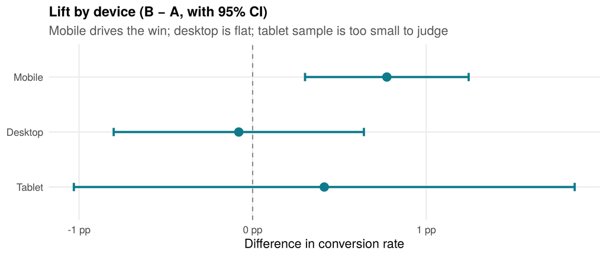

```r
ggplot(seg, aes(x = (rateB - rateA), y = reorder(device, nA + nB))) +
  geom_vline(xintercept = 0, linetype = "dashed", colour = "grey50") +
  geom_errorbarh(aes(xmin = lo, xmax = hi), height = 0.15, colour = col_B, linewidth = 1) +
  geom_point(size = 3.5, colour = col_B) +
  scale_x_continuous(labels = function(x) paste0(round(x * 100, 1), " pp")) +
  labs(title = "Lift by device (B − A, with 95% CI)",
       subtitle = "Mobile drives the win; desktop is flat; tablet sample is too small to judge",
       x = "Difference in conversion rate", y = NULL)
```

```r
int_test <- anova(glm(converted ~ variant + device, data = ab, family = binomial),
                  glm(converted ~ variant * device, data = ab, family = binomial),
                  test = "Chisq")
```

- **Mobile** shows a 37% lift that survives correction for testing multiple segments (Holm-adjusted p = 0.004) — consistent with B’s shorter form being easier on a phone.
- **Desktop** shows essentially no change (-2%).
- **Tablet** rests on only ~1,000 visitors per arm — the interval is huge, so it’s not evidence of anything either way.
- A formal interaction test (does the effect differ by device?) gives p = 0.062, so this pattern is **suggestive, not conclusive** — the right move is a follow-up test, not a victory lap.

> **Why the correction matters:** slice a test into enough segments and *something* will look significant by chance. Adjusting p-values for the number of comparisons is what separates analysis from data-dredging.

# 8. The peeking trap: why the decision date was fixed

A very common mistake is checking results every day and stopping the moment p < 0.05. Here is the day-by-day p-value for this test:

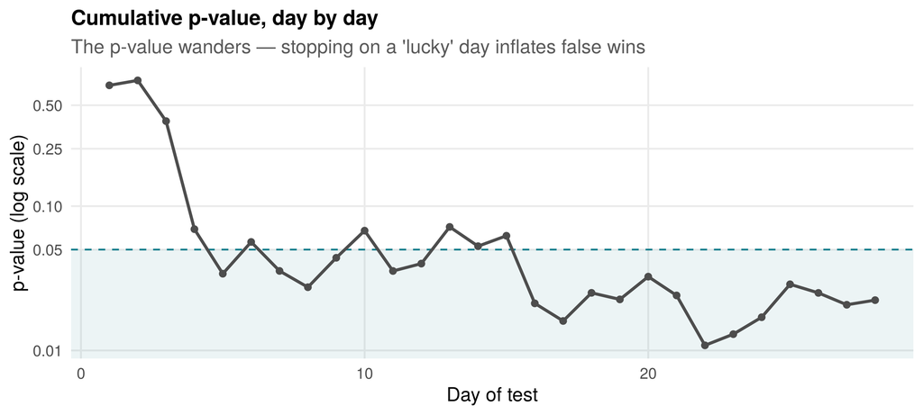

```r
daily <- ab %>% arrange(date) %>% group_by(date, variant) %>%
  summarise(n = n(), x = sum(converted), .groups = "drop") %>%
  pivot_wider(names_from = variant, values_from = c(n, x)) %>%
  mutate(across(c(n_A, n_B, x_A, x_B), cumsum),
         day = row_number())
daily$p <- mapply(function(xa, na, xb, nb) prop.test(c(xb, xa), c(nb, na), correct = FALSE)$p.value,
                  daily$x_A, daily$n_A, daily$x_B, daily$n_B)

ggplot(daily, aes(day, p)) +
  annotate("rect", xmin = -Inf, xmax = Inf, ymin = 0, ymax = 0.05, fill = col_B, alpha = 0.08) +
  geom_hline(yintercept = 0.05, linetype = "dashed", colour = col_B) +
  geom_line(colour = "grey30", linewidth = 0.9) + geom_point(size = 1.6, colour = "grey30") +
  scale_y_continuous(trans = "log10", breaks = c(0.01, 0.05, 0.1, 0.25, 0.5, 1)) +
  labs(title = "Cumulative p-value, day by day",
       subtitle = "The p-value wanders — stopping on a 'lucky' day inflates false wins",
       x = "Day of test", y = "p-value (log scale)")
```

To show how dangerous this is, I simulated **2,000 A/A tests** — tests where *both* pages are identical, so every “winner” is a false alarm — and compared two analysts:

```r
n_sims <- 2000; days <- 28; per_day <- 450; p0 <- 0.03
fixed_fp <- peek_fp <- logical(n_sims)
for (s in seq_len(n_sims)) {
  xa <- cumsum(rbinom(days, per_day, p0)); xb <- cumsum(rbinom(days, per_day, p0))
  n  <- per_day * seq_len(days)
  pooled <- (xa + xb) / (2 * n)
  z  <- (xb / n - xa / n) / sqrt(pooled * (1 - pooled) * 2 / n)
  pv <- 2 * pnorm(-abs(z))
  fixed_fp[s] <- pv[days] < 0.05          # analyst checks once, on day 28
  peek_fp[s]  <- any(pv[3:days] < 0.05)   # analyst checks daily, stops at first p < 0.05
}

data.frame(Analyst = c("Disciplined: analyses once at the planned end",
                       "Impatient: peeks daily, stops at first p < 0.05"),
           `False 'winners' declared` = pct(c(mean(fixed_fp), mean(peek_fp)), 1),
           check.names = FALSE)
```

| Analyst | False ‘winners’ declared |
| --- | --- |
| Disciplined: analyses once at the planned end | 4.4% |
| Impatient: peeks daily, stops at first p < 0.05 | 23.0% |

Same data-generating process, same 5% threshold — but daily peeking **multiplies the false-positive rate by about 5×**. That is why this test had a pre-registered sample size and end date, and why the result above can be trusted. (If a business genuinely needs to monitor continuously, the fix is a sequential design such as alpha-spending or a Bayesian decision rule — not ad-hoc peeking.)

# 9. Business impact

```r
monthly_visitors <- round(nrow(ab) / 28 * 30)
extra_lo  <- monthly_visitors * pA * lift_ci[1]
extra_mid <- monthly_visitors * pA * rel_lift
extra_hi  <- monthly_visitors * pA * lift_ci[2]
# Revenue impact uses revenue-per-visitor, NOT extra enrolments x order value:
# B also lowers spend among buyers who would have bought anyway, and only RPV
# captures both effects at once.
rpv_diff <- mean(rev_B) - mean(rev_A)
rev_lo  <- monthly_visitors * rpv_ci[1]
rev_mid <- monthly_visitors * rpv_diff
rev_hi  <- monthly_visitors * rpv_ci[2]

data.frame(Scenario = c("Conservative (low end of 95% CI)", "Most likely (point estimate)",
                        "Optimistic (high end of 95% CI)"),
           `Extra enrolments / month` = round(c(extra_lo, extra_mid, extra_hi)),
           `Revenue change / month*` = dollar(round(unname(c(rev_lo, rev_mid, rev_hi)))),
           check.names = FALSE)
```

| Scenario | Extra enrolments / month | Revenue change / month* |
| --- | --- | --- |
| Conservative (low end of 95% CI) | 16 | -$5,226 |
| Most likely (point estimate) | 139 | $4,242 |
| Optimistic (high end of 95% CI) | 277 | $13,796 |

*Based on ~30,970 visitors/month and the revenue-per-visitor confidence interval from Section 5.

The two columns tell different stories, and that’s the point. Enrolments rise in every scenario (roughly 16 to 277 more students a month). Revenue could rise by up to $13,796 a month — or **fall** by up to $5,226 if B’s downgrade effect on the Pro bundle dominates. That uncertainty is exactly why the recommendation below fixes the upsell before booking any revenue gain.

# 10. Recommendation & limitations

**Decision**

1. **Ship Version B to mobile traffic now.** The lift there is large, survives multiple-comparison correction, and the risk of hurting conversion is negligible.
2. **Keep A vs B running on desktop** — there’s no evidence B helps there, and no reason to change what works.
3. **Fix the upsell on B.** Add the Pro bundle’s benefits to the redesigned page, then re-test with revenue per visitor as the primary metric.

**Limitations**

- 28 days captures four weekly cycles but not seasonality (e.g., exam periods, new-year resolutions).
- Novelty effect: a fresh design can over-perform briefly; monitor the post-launch conversion rate for decay.
- Revenue is measured at purchase only — refunds and course completion (the real value drivers) aren’t in the data.
- The dataset is synthetic, built to mirror real-world traffic patterns, so the methodology can be shared publicly.

Methods used: power analysis · sample-ratio-mismatch test · two-proportion z-test · bootstrap confidence intervals · permutation test · Bayesian Beta-Binomial model · Welch t-test · logistic regression · Holm multiple-comparison correction · interaction test · Monte-Carlo simulation of A/A tests. Built with R (`dplyr`, `ggplot2`, `rmarkdown`).